# The raw code for this IPython notebook is hidden for easier reading. # To toggle on/off the raw code, click here.

# Introduction: The Carpentries

# The Carpentries: Programmatic Assessment Report

#### Authors: Maneesha Sane, Erin Becker

### What is The Carpentries?

Software Carpentry (SWC) and Data Carpentry (DC) are two programs of The Carpentries (a fiscally sponsored project of Community Initiatives). We teach essential computing and data skills. We exist because the skills needed to do computational, data-intensive research are not part of basic research training in most disciplines.

### About Software Carpentry

Software Carpentry enables researchers to create purpose-built tools, whether it be a Unix shell script to automate repetitive tasks, or software code in programming languages such as Python, R, or MATLAB. These enable researchers to build programs that can be read, re-used, and validated, greatly enhancing the sharing and reproducibility of their research.

### About Data Carpentry

Data Carpentry learners are taught to work with data more effectively. Workshops focus on the data lifecycle, covering data organization, cleaning and management through to data analysis and visualization. Lessons are domain-specific, with coverage in biology, genomics, and social sciences.

### What The Carpentries offers

- A suite of open source, collaboratively-built, community-developed lessons
- Workshops based on a learn-by-doing, ‘code with me’ approach
- A supportive learning culture
- Instructor training, mentoring and support
- Active global community which subscribes to an inclusive code of conduct
- Evidence-based, proven pedagogical training methods
- Ongoing development opportunities via our webinar series
- Open discussions

The Carpentries began systematically recording data for our workshops in 2012. We use this data to investigate how The Carpentries has grown over the years including number and geographic reach of our workshops, and learners at these workshops. We also look at our Instructor Training program, including number and geographic reach of instructor training events, number of trainees and their completion rates, and onboarding of new Instructor Trainers.

Data are collected by a team of Workshop Administrators. In Africa, Australia, Canada, New Zealand, and the United Kingdom, Workshop Administrators are affiliated with our member institutions and provide in-kind staff time. A full-time Carpentries staff member is the Workshop Administrator for the rest the world.

# Introduction: This Report

### Section 1:

This section revisits data and projections made in an earlier report, noting specific instances of unexpected growth or reach to new communities.

### Section 2: Instructor Training Applications

For this report, we reviewed the applications that came to our instructor training program. The goal was to be able to compare the applicant pool with the badged instructor pool and to be able to look at application and completion rates across certain characteristics. These findings are explored further below.

# Section 1

We revisited some of the data explored in an [earlier report](https://github.com/carpentries/assessment/blob/master/programmatic-assessment/workshops/programmatic_data_2018Q2.ipynb). Looking at our expected growth, we see that projections for the number of workshops in 2018 have not changed significantly from the first quarter to the second quarter.

We did see geographic growth. In June 2018, The Carpentries saw its first workshop in Pakistan. By the second quarter of 2018, we also saw Ethiopia join the ranks of countries hosting 10 or more workshops. This happened in only two years, representing the remarkable growth of The Carpentries community across Africa.

### Figure X: Workshops by Carpentry by Year

This bar chart shows the number of Data Carpentry (DC) and Software Carpentry (SWC) workshops each year. Data for 2018 is a projection. The proportion of workshops in the first two quarters of 2017 relative to the full year was applied to actual first two quarters data from 2018 to calculate this projection. Source data can be found in Table 1 in the Appendix.

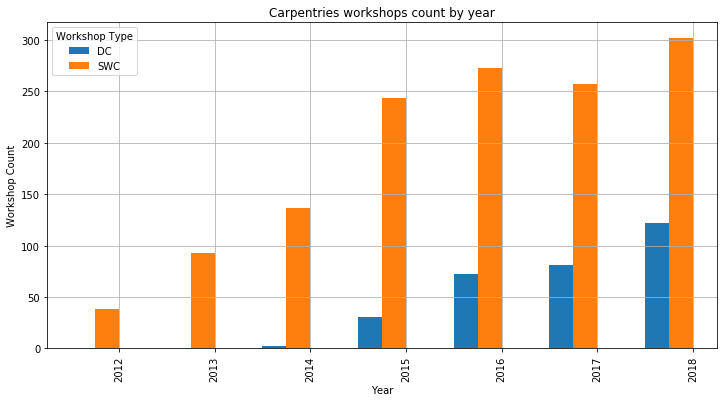

### Figure X: First workshop by year

This map notes the year each country held its first workshop.

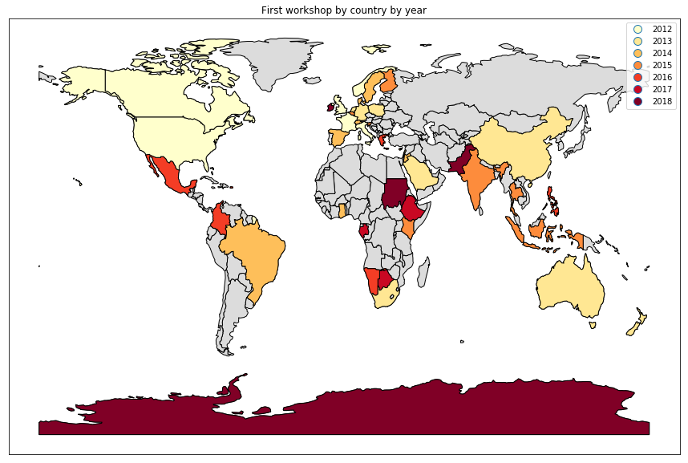

### Figure X: Countries hosting 10 or more workshops

This chart notes all countries hosting 10 or more workshops (lifetime).

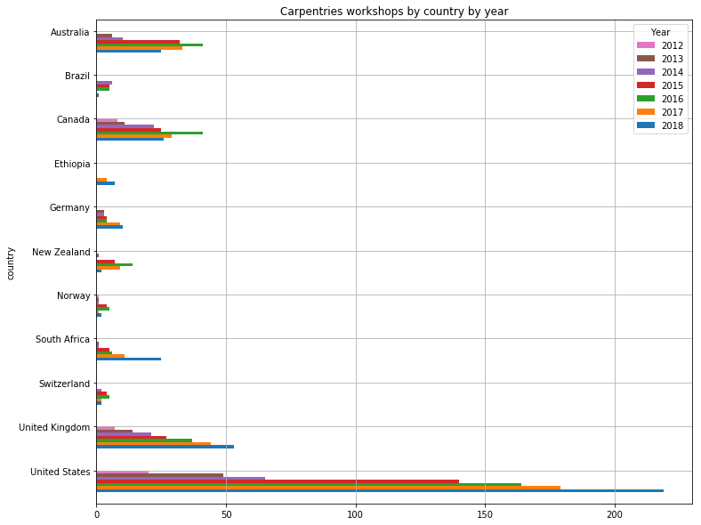

# Section 2

The Carpentries runs instructor training events as a benefit to member sites who want to build a pool of onsite instructors, increasing their capacity to run self organized, onsite workshops for their community. When possible, The Carpentries also offers seats in theses events to those applying from an open pool, as a way to increase our reach and connect with individuals who may not otherwise have access to our resources.

This two-day class has the following overall goals:

- Introduce you to evidence-based best-practices of teaching.
- Teach you how to create a positive environment for learners at your workshops.
- Provide opportunities for you to practice and build your teaching skills.
- Help you become integrated into the Carpentry community.
- Prepare you to use these teaching skills in teaching Carpentry workshops.

Because we have only two days, some things are beyond the scope of this class. We will not be learning:

- How to program in R or Python, use git, or any of the other topics taught in Carpentry workshops.
- How to create your own lessons from scratch (although you will have a good start on the principles behind that sort of work if you’re inspired to learn more).

For this report, we looked at all applications that came in through our open application process (those that did not specifically identify themselves with a member site), from July 1, 2016 through June 30, 2018. In looking at completion rates, we only looked at people who attended events before March 31, 2018. Because all trainees have three months to complete the checkout process, those who attended later would not be expected to complete certification before June 30, 2018. We chose not to include applications from member sites, as these trainees are selected by the member site, and do not go through our review process.

This review included

- Open Training applications (n=892)
- Attendees at open training events (n=454)
- Badged instructors from open training events (n=257)

This represents an overall completion rate of 56.6%. In this report, we compare this overall completion rate with completion rates by country, by occupation, by previous training in teaching, previous experience in teaching, programming language experience, previous involvement with The Carpentries, and areas of expertise.

# Open Applications by Month

We begin our analysis by looking at the frequency of open applications.

July 2016 is likely an anomoly as that is when we introduced this application process and may show a surge in applications because of people who were waiting on new process to apply. Excluding this outlier, we saw an average of 33 applications per month, or approximately one a day. This demonstrates a strong demand for our instructor training from people who may not be affiliated with a member site.

### Figure X: Open Applications by Month

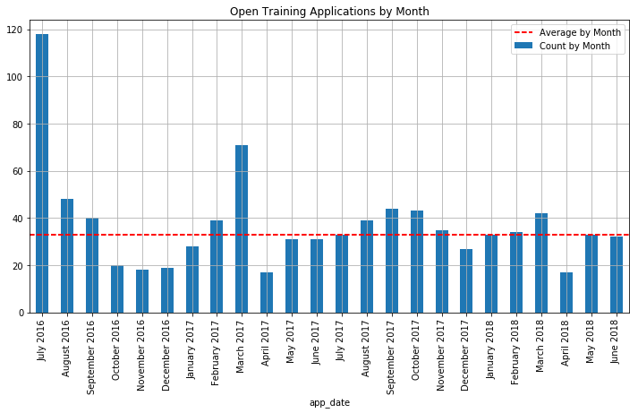

# Open Applications by Country

We began by looking at the number of applications that came in by country. Unsurprisingly, the United States dominates in the number of applications we receive. Even outside of the United States, we see many more applications from predominantly white, predominantly English speaking parts of the world.

### Figure X: Applications by Country (bar chart)

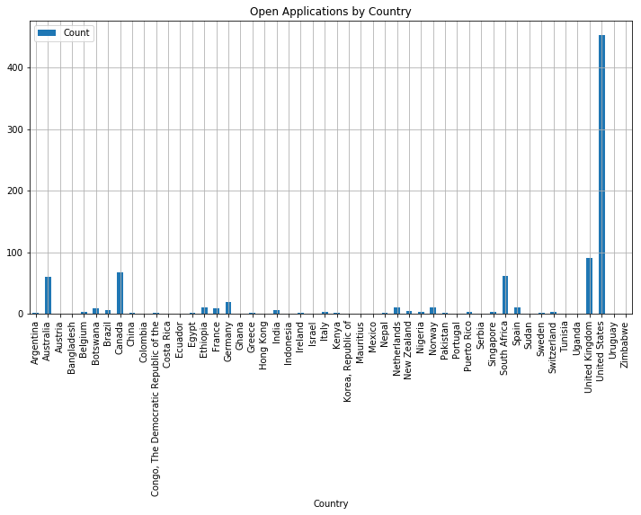

### Figure X: Completion Rates by Country (bar chart)

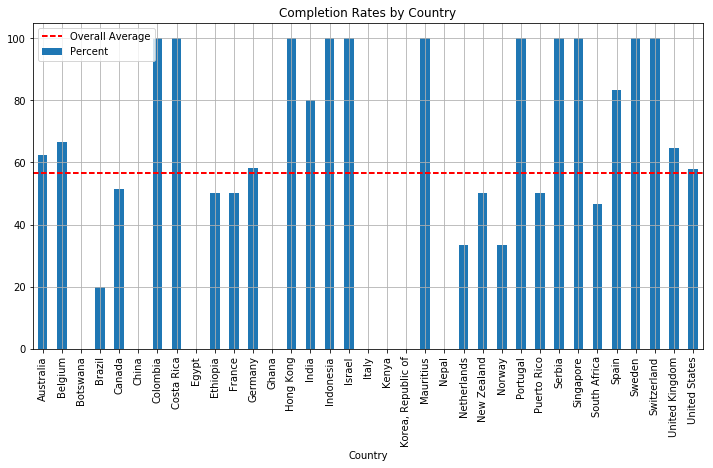

### Figure X: Applications by country (map)

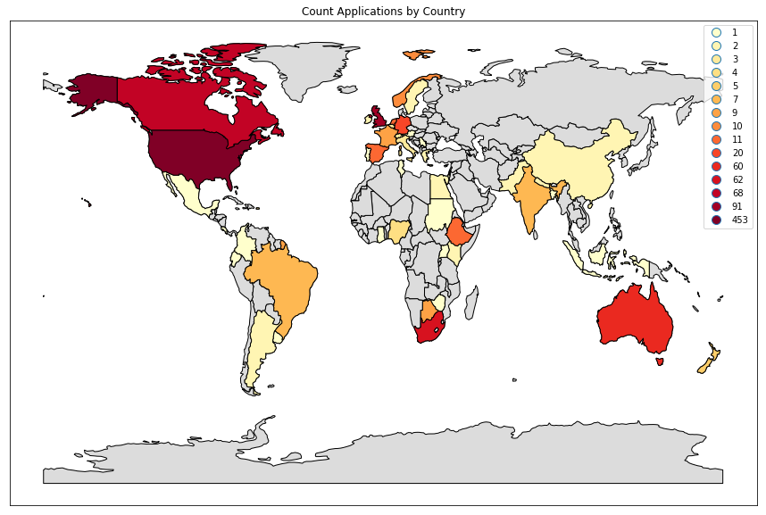

### Figure X: Completion rates by country (map)

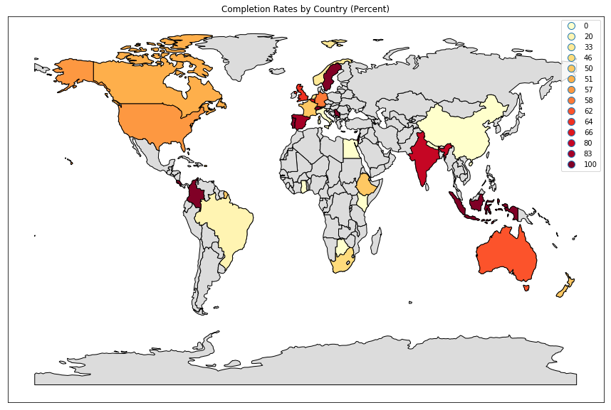

# Open Applications by Occupation

We see high completion rates for researchers and librarians, perhaps demonstrating these are the people using the technology skills we teach regularly and are in a position to share these tools with others. While undergraduates also have high completion rates, this may be skewed by the fact that they represent a small percentage of our overall applications.

### Figure X: Open Applications by Occupation

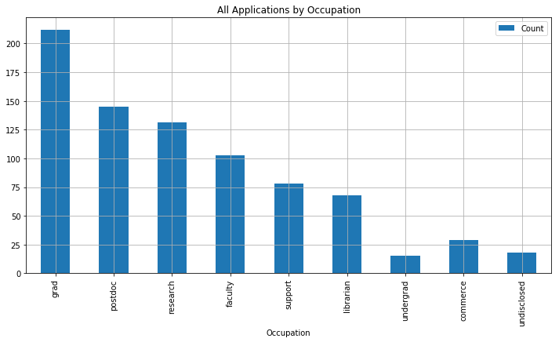

### Figure X: Completion Rates by Occupation

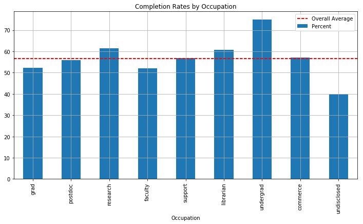

# Open Applications by Previous Training in Teaching

At the same time, people with at least some previous training in teaching tend to certify at higher rates, possibly indicating that coming in with some teaching background motivates people to continue through the Carpentries certification process.

### Figure X: Open Applications by Previous Training in Teaching

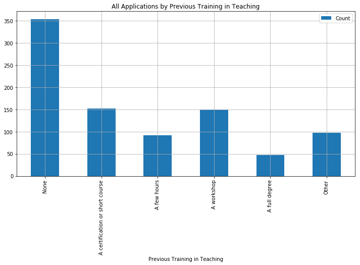

### Figure X: Completion Rates by Previous Training in Teaching

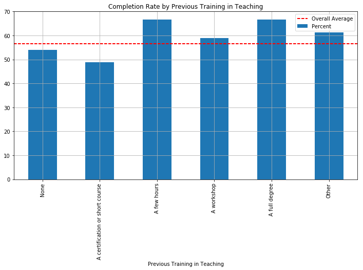

# Open Applications by Previous Experience in Teaching

### Figure X: Open Applications by Previous Experience in Teaching

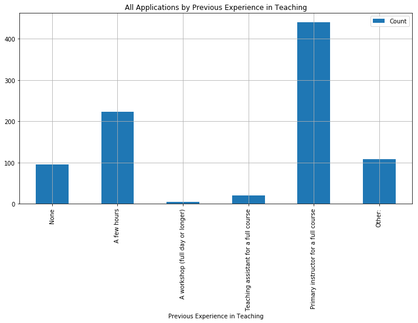

### Figure X: Completion Rates by Previous Experience in Teaching

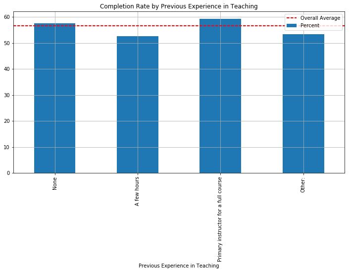

# Open Applications by Programming Language Usage

The majority of our applications come from people who use a programming language frequently -- daily or several times a week. Certification rates are also lower among those who use a programming language infrequenty. In presenting our instructor training program to member sites and to the broader community, we emphasize that our training is about pedagogy, cognitive psychology, and how to teach. We note that techinical skills are not taught. However, the aim of our instructor training program is to prepare people to teach our curriculum, which includes programming languages like R and Python, as well as other computational programming skills like version control in git. We may be seeing a subset of our applicant pool who are looking to improve their teaching skills, but do not badge because they do not feel prepared to teach the tools we teach in our workshops.

### Figure X: Open Applications by Programming Langauge Usage

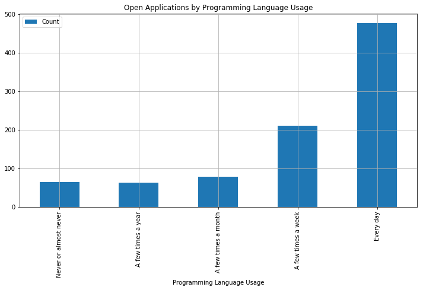

### Figure X: Completion Rates by Programming Language Usage

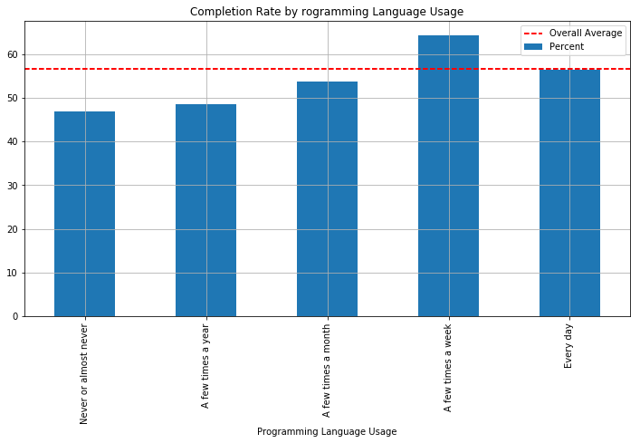

# Open Applications by Previous Involvement

We looked at our applications by previous involvement with The Carpentries. Applicants could self-certify that they had experience as a helper, instructor, host, organize, or contributor. Many applicants had multiple roles. We can not directly compare between groups as many people held more than one role. However, we can look at some characteristics of each group.

People who have had previous experience with The Carpentries (helpers, hosts, instructors, contributors) all badge at highest levels, higher than overall average. These are people who have had deeper experiences with The Carpentries, have more buy in and motivation, and are already coming in knowing about how we work. This may indicate that people who have seen our teaching practices, and are familiar with our curriculum are motivated to complete the certification process to make them official Carpentries instructors.

### Open Applications by Previous Involvement with The Carpentries

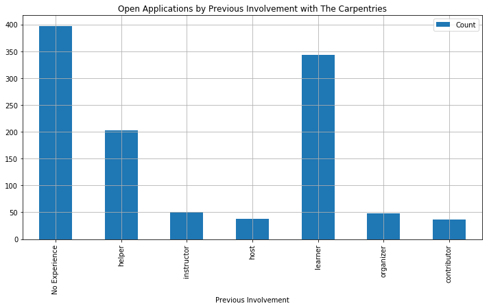

### Figure X: Completion Rate by Previous Involvement with The Carpentries

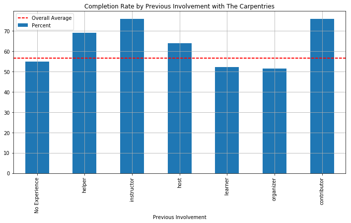

# Open Applications by Areas of Expertise

We looked at our applications by area of expertise. Applicants could self-certify their areas of expertise. Many applicants identify with multiple domains. We can not directly compare between groups. However, we can look at some characteristics of each group.

### Findings

The majority of applications come from people with one of these backgrounds: Computer Science/Electrical Engineering; Genetics, genomics, bioinformatics; High Performance Computing; Mathematics/Statistics; Organismal Biology. However, none of these groups are represented in those with the highest certification rates.

Through a [recent grant from the Alfred P. Sloan Foundation](https://datacarpentry.org/blog/2018/02/curriculum-dev-scaling) we are expanding our reach to new curricula including Social Sciences, Chemistry, and Economics. The data here show the importance of developing strategies for recruiting new instrucotrs and onboarding existing instructors to develop, teach, and maintain these lessons.

### Figure X: Open Applications by Area of Expertise

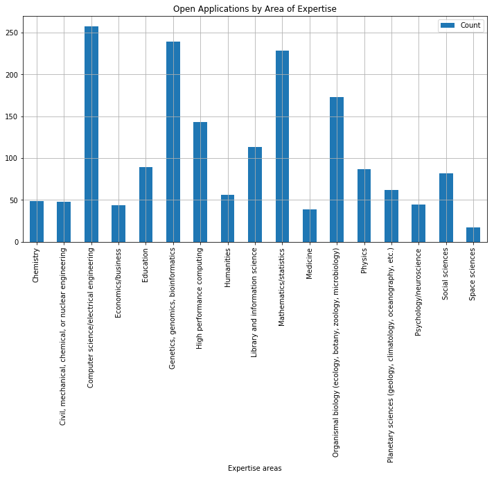

### Figure X: Completion Rates by Area of Expertise

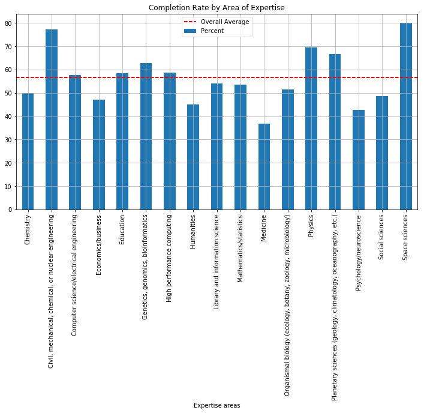

# Appendix

The following tables show the number of applications, number of training attendees, and number of badged instructors by characteristics in each category.

- Open training applications: n = 892
- Open training attendees: n = 454
- Open training badged instructors: n = 257
- Represents overall completion rate of 56.6%

## Table X: Workshops by Carpentry By Year

This table shows the number of Data Carpentry (DC) and Software Carpentry (SWC) workshops each year. Data for 2018 is a projection. The proportion of workshops in the first two quarters of 2017 relative to the full year was applied to actual first two quarters data from 2018.

| Workshop Type Year | DC | SWC | row total |
| --- | --- | --- | --- |
| 2012 | 0 | 38 | 38 |
| 2013 | 0 | 93 | 93 |
| 2014 | 2 | 137 | 139 |
| 2015 | 31 | 243 | 274 |
| 2016 | 72 | 273 | 345 |
| 2017 | 81 | 257 | 338 |
| 2018 | 122 | 302 | 424 |
| column total | 308 | 1343 | 1651 |

## Table X: List of countries that held their first workshop each year

| year | name |
| --- | --- |
| 2012 | France |
| 2012 | United Kingdom |
| 2012 | United States |
| 2012 | Italy |
| 2012 | Canada |
| 2012 | Norway |
| 2013 | New Zealand |
| 2013 | Poland |
| 2013 | Saudi Arabia |
| 2013 | Germany |
| 2013 | South Africa |
| 2013 | Lebanon |
| 2013 | Netherlands |
| 2013 | China |
| 2013 | Australia |
| 2014 | Sweden |
| 2014 | Denmark |
| 2014 | Ghana |
| 2014 | Cyprus |
| 2014 | Switzerland |
| 2014 | Brazil |
| 2014 | Jordan |
| 2014 | Spain |
| 2015 | Slovenia |
| 2015 | Thailand |
| 2015 | Kenya |
| 2015 | Venezuela, Bolivarian Republic of |
| 2015 | Belgium |
| 2015 | Korea, Republic of |
| 2015 | Finland |
| 2015 | Indonesia |
| 2015 | India |
| 2016 | Namibia |
| 2016 | Colombia |
| 2016 | Mexico |
| 2016 | Greece |
| 2016 | Philippines |
| 2016 | Puerto Rico |
| 2017 | Gabon |
| 2017 | Ethiopia |
| 2017 | Botswana |
| 2017 | Mauritius |
| 2018 | Pakistan |
| 2018 | Sudan |
| 2018 | Ireland |
| 2018 | Antarctica |

## Table X: Total workshops by country by year

| start_date country | 2012 | 2013 | 2014 | 2015 | 2016 | 2017 | 2018 | row total |
| --- | --- | --- | --- | --- | --- | --- | --- | --- |
| Antarctica | 0 | 0 | 0 | 0 | 0 | 0 | 1 | 1 |
| Australia | 0 | 6 | 10 | 32 | 41 | 33 | 14 | 136 |
| Belgium | 0 | 0 | 0 | 1 | 0 | 1 | 1 | 3 |
| Botswana | 0 | 0 | 0 | 0 | 0 | 1 | 0 | 1 |
| Brazil | 0 | 0 | 6 | 5 | 5 | 0 | 1 | 17 |
| Canada | 8 | 11 | 22 | 25 | 41 | 29 | 13 | 149 |
| China | 0 | 1 | 0 | 0 | 0 | 0 | 0 | 1 |
| Colombia | 0 | 0 | 0 | 0 | 1 | 0 | 0 | 1 |
| Cyprus | 0 | 0 | 1 | 0 | 0 | 0 | 0 | 1 |
| Denmark | 0 | 0 | 1 | 0 | 2 | 3 | 1 | 7 |
| Ethiopia | 0 | 0 | 0 | 0 | 0 | 4 | 7 | 11 |
| Finland | 0 | 0 | 0 | 2 | 0 | 0 | 1 | 3 |
| France | 1 | 2 | 0 | 1 | 3 | 0 | 2 | 9 |
| Gabon | 0 | 0 | 0 | 0 | 0 | 1 | 0 | 1 |
| Germany | 0 | 3 | 3 | 4 | 4 | 9 | 7 | 30 |
| Ghana | 0 | 0 | 1 | 0 | 0 | 1 | 0 | 2 |
| Greece | 0 | 0 | 0 | 0 | 1 | 0 | 0 | 1 |
| India | 0 | 0 | 0 | 1 | 0 | 0 | 0 | 1 |
| Indonesia | 0 | 0 | 0 | 1 | 0 | 0 | 0 | 1 |
| Ireland | 0 | 0 | 0 | 0 | 0 | 0 | 2 | 2 |
| Italy | 1 | 0 | 1 | 0 | 2 | 0 | 1 | 5 |
| Jordan | 0 | 0 | 1 | 0 | 0 | 0 | 0 | 1 |
| Kenya | 0 | 0 | 0 | 1 | 1 | 0 | 0 | 2 |
| Korea, Republic of | 0 | 0 | 0 | 4 | 1 | 0 | 0 | 5 |
| Lebanon | 0 | 1 | 0 | 0 | 0 | 0 | 0 | 1 |
| Mauritius | 0 | 0 | 0 | 0 | 0 | 1 | 0 | 1 |
| Mexico | 0 | 0 | 0 | 0 | 1 | 1 | 1 | 3 |
| Namibia | 0 | 0 | 0 | 0 | 1 | 1 | 0 | 2 |
| Netherlands | 0 | 1 | 0 | 3 | 2 | 2 | 1 | 9 |
| New Zealand | 0 | 1 | 0 | 7 | 14 | 9 | 2 | 33 |
| Norway | 1 | 1 | 1 | 4 | 5 | 1 | 2 | 15 |
| Pakistan | 0 | 0 | 0 | 0 | 0 | 0 | 1 | 1 |
| Philippines | 0 | 0 | 0 | 0 | 1 | 0 | 0 | 1 |
| Poland | 0 | 1 | 1 | 2 | 4 | 1 | 0 | 9 |
| Puerto Rico | 0 | 0 | 0 | 0 | 1 | 0 | 0 | 1 |
| Saudi Arabia | 0 | 1 | 0 | 0 | 0 | 0 | 0 | 1 |
| Slovenia | 0 | 0 | 0 | 1 | 0 | 0 | 0 | 1 |
| South Africa | 0 | 1 | 1 | 5 | 6 | 11 | 7 | 31 |
| Spain | 0 | 0 | 1 | 1 | 1 | 2 | 1 | 6 |
| Sudan | 0 | 0 | 0 | 0 | 0 | 0 | 1 | 1 |
| Sweden | 0 | 0 | 1 | 1 | 1 | 1 | 3 | 7 |
| Switzerland | 0 | 0 | 2 | 4 | 5 | 2 | 2 | 15 |
| Thailand | 0 | 0 | 0 | 1 | 0 | 1 | 0 | 2 |
| United Kingdom | 7 | 14 | 21 | 27 | 37 | 44 | 23 | 173 |
| United States | 20 | 49 | 65 | 140 | 164 | 179 | 109 | 726 |
| Venezuela, Bolivarian Republic of | 0 | 0 | 0 | 1 | 0 | 0 | 0 | 1 |
| column total | 38 | 93 | 139 | 274 | 345 | 338 | 204 | 1431 |

## Open Applications by month

This table shows the number of applications we received each month for our open training seats.

|  | app_date | count |
| --- | --- | --- |
| 0 | July 2016 | 118 |
| 1 | August 2016 | 48 |
| 2 | September 2016 | 40 |
| 3 | October 2016 | 20 |
| 4 | November 2016 | 18 |
| 5 | December 2016 | 19 |
| 6 | January 2017 | 28 |
| 7 | February 2017 | 39 |
| 8 | March 2017 | 71 |
| 9 | April 2017 | 17 |
| 10 | May 2017 | 31 |
| 11 | June 2017 | 31 |
| 12 | July 2017 | 33 |
| 13 | August 2017 | 39 |
| 14 | September 2017 | 44 |
| 15 | October 2017 | 43 |
| 16 | November 2017 | 35 |
| 17 | December 2017 | 27 |
| 18 | January 2018 | 33 |
| 19 | February 2018 | 34 |
| 20 | March 2018 | 42 |
| 21 | April 2018 | 17 |
| 22 | May 2018 | 33 |
| 23 | June 2018 | 32 |

## Open Applications by country

```
Open Applications by Country
```

|  | Country | Count |
| --- | --- | --- |
| 26 | Argentina | 2 |
| 4 | Australia | 60 |
| 39 | Austria | 1 |
| 41 | Bangladesh | 1 |
| 17 | Belgium | 3 |
| 11 | Botswana | 9 |
| 13 | Brazil | 7 |
| 2 | Canada | 68 |
| 25 | China | 2 |
| 44 | Colombia | 1 |
| 27 | Congo, The Democratic Republic of the | 2 |
| 45 | Costa Rica | 1 |
| 31 | Ecuador | 1 |
| 21 | Egypt | 2 |
| 7 | Ethiopia | 11 |
| 10 | France | 9 |
| 5 | Germany | 20 |
| 34 | Ghana | 1 |
| 29 | Greece | 2 |
| 37 | Hong Kong | 1 |
| 12 | India | 7 |
| 35 | Indonesia | 1 |
| 24 | Ireland | 2 |
| 38 | Israel | 1 |
| 19 | Italy | 3 |
| 28 | Kenya | 2 |
| 43 | Korea, Republic of | 1 |
| 49 | Mauritius | 1 |
| 32 | Mexico | 1 |
| 30 | Nepal | 2 |
| 6 | Netherlands | 11 |
| 14 | New Zealand | 5 |
| 15 | Nigeria | 4 |
| 9 | Norway | 10 |
| 22 | Pakistan | 2 |
| 42 | Portugal | 1 |
| 18 | Puerto Rico | 3 |
| 33 | Serbia | 1 |
| 20 | Singapore | 3 |
| 3 | South Africa | 62 |
| 8 | Spain | 11 |
| 40 | Sudan | 1 |
| 23 | Sweden | 2 |
| 16 | Switzerland | 3 |
| 46 | Tunisia | 1 |
| 36 | Uganda | 1 |
| 1 | United Kingdom | 91 |
| 0 | United States | 453 |
| 47 | Uruguay | 1 |
| 48 | Zimbabwe | 1 |

```
Open Application Attendees by Country
```

|  | Country | Count |
| --- | --- | --- |
| 4 | Australia | 32 |
| 13 | Belgium | 3 |
| 15 | Botswana | 3 |
| 10 | Brazil | 5 |
| 3 | Canada | 33 |
| 33 | China | 1 |
| 32 | Colombia | 1 |
| 29 | Costa Rica | 1 |
| 17 | Egypt | 2 |
| 12 | Ethiopia | 4 |
| 7 | France | 6 |
| 5 | Germany | 12 |
| 21 | Ghana | 1 |
| 28 | Hong Kong | 1 |
| 9 | India | 5 |
| 27 | Indonesia | 1 |
| 24 | Israel | 1 |
| 16 | Italy | 2 |
| 31 | Kenya | 1 |
| 20 | Korea, Republic of | 1 |
| 23 | Mauritius | 1 |
| 34 | Nepal | 1 |
| 8 | Netherlands | 6 |
| 11 | New Zealand | 4 |
| 14 | Norway | 3 |
| 22 | Portugal | 1 |
| 18 | Puerto Rico | 2 |
| 25 | Serbia | 1 |
| 30 | Singapore | 1 |
| 2 | South Africa | 45 |
| 6 | Spain | 6 |
| 26 | Sweden | 1 |
| 19 | Switzerland | 2 |
| 1 | United Kingdom | 62 |
| 0 | United States | 202 |

```
Open Application Badged Instructors by Country
```

|  | Country | Count |
| --- | --- | --- |
| 3 | Australia | 20 |
| 11 | Belgium | 2 |
| 18 | Brazil | 1 |
| 4 | Canada | 17 |
| 17 | Colombia | 1 |
| 20 | Costa Rica | 1 |
| 10 | Ethiopia | 2 |
| 8 | France | 3 |
| 5 | Germany | 7 |
| 19 | Hong Kong | 1 |
| 7 | India | 4 |
| 14 | Indonesia | 1 |
| 24 | Israel | 1 |
| 26 | Mauritius | 1 |
| 9 | Netherlands | 2 |
| 12 | New Zealand | 2 |
| 22 | Norway | 1 |
| 25 | Portugal | 1 |
| 16 | Puerto Rico | 1 |
| 15 | Serbia | 1 |
| 23 | Singapore | 1 |
| 2 | South Africa | 21 |
| 6 | Spain | 5 |
| 21 | Sweden | 1 |
| 13 | Switzerland | 2 |
| 1 | United Kingdom | 40 |
| 0 | United States | 117 |

```
Open Application Completion Rates by Country
```

|  | Country | Count Attended | Count Badged | Percent |
| --- | --- | --- | --- | --- |
| 0 | Australia | 32 | 20 | 62.50 |
| 1 | Belgium | 3 | 2 | 66.67 |
| 2 | Botswana | 3 | 0 | 0.00 |
| 3 | Brazil | 5 | 1 | 20.00 |
| 4 | Canada | 33 | 17 | 51.52 |
| 5 | China | 1 | 0 | 0.00 |
| 6 | Colombia | 1 | 1 | 100.00 |
| 7 | Costa Rica | 1 | 1 | 100.00 |
| 8 | Egypt | 2 | 0 | 0.00 |
| 9 | Ethiopia | 4 | 2 | 50.00 |
| 10 | France | 6 | 3 | 50.00 |
| 11 | Germany | 12 | 7 | 58.33 |
| 12 | Ghana | 1 | 0 | 0.00 |
| 13 | Hong Kong | 1 | 1 | 100.00 |
| 14 | India | 5 | 4 | 80.00 |
| 15 | Indonesia | 1 | 1 | 100.00 |
| 16 | Israel | 1 | 1 | 100.00 |
| 17 | Italy | 2 | 0 | 0.00 |
| 18 | Kenya | 1 | 0 | 0.00 |
| 19 | Korea, Republic of | 1 | 0 | 0.00 |
| 20 | Mauritius | 1 | 1 | 100.00 |
| 21 | Nepal | 1 | 0 | 0.00 |
| 22 | Netherlands | 6 | 2 | 33.33 |
| 23 | New Zealand | 4 | 2 | 50.00 |
| 24 | Norway | 3 | 1 | 33.33 |
| 25 | Portugal | 1 | 1 | 100.00 |
| 26 | Puerto Rico | 2 | 1 | 50.00 |
| 27 | Serbia | 1 | 1 | 100.00 |
| 28 | Singapore | 1 | 1 | 100.00 |
| 29 | South Africa | 45 | 21 | 46.67 |
| 30 | Spain | 6 | 5 | 83.33 |
| 31 | Sweden | 1 | 1 | 100.00 |
| 32 | Switzerland | 2 | 2 | 100.00 |
| 33 | United Kingdom | 62 | 40 | 64.52 |
| 34 | United States | 202 | 117 | 57.92 |

## Open Applications by Occupation

```
Open Applications by Occupation
```

|  | Occupation | Count |
| --- | --- | --- |
| 0 | grad | 212 |
| 1 | postdoc | 145 |
| 2 | research | 131 |
| 3 | faculty | 103 |
| 4 | support | 78 |
| 5 | librarian | 68 |
| 8 | undergrad | 15 |
| 6 | commerce | 29 |
| 7 | undisclosed | 18 |

```
Open Application Attendees by Occupation
```

|  | Occupation | Count |
| --- | --- | --- |
| 0 | grad | 109 |
| 2 | postdoc | 77 |
| 1 | research | 78 |
| 4 | faculty | 48 |
| 3 | support | 51 |
| 5 | librarian | 28 |
| 6 | undergrad | 8 |
| 7 | commerce | 7 |
| 8 | undisclosed | 5 |

```
Open Application Badged Instructors by Occupation
```

|  | Occupation | Count |
| --- | --- | --- |
| 0 | grad | 57 |
| 2 | postdoc | 43 |
| 1 | research | 48 |
| 4 | faculty | 25 |
| 3 | support | 29 |
| 5 | librarian | 17 |
| 6 | undergrad | 6 |
| 7 | commerce | 4 |
| 8 | undisclosed | 2 |

```
Open Application Completion Rates by Occupation
```

|  | Occupation | Count Attended | Count Badged | Percent |
| --- | --- | --- | --- | --- |
| 0 | grad | 109 | 57 | 52.29 |
| 1 | postdoc | 77 | 43 | 55.84 |
| 2 | research | 78 | 48 | 61.54 |
| 3 | faculty | 48 | 25 | 52.08 |
| 4 | support | 51 | 29 | 56.86 |
| 5 | librarian | 28 | 17 | 60.71 |
| 6 | undergrad | 8 | 6 | 75.00 |
| 7 | commerce | 7 | 4 | 57.14 |
| 8 | undisclosed | 5 | 2 | 40.00 |

## Open Applications by Previous Training in Teaching

```
Open Applications by Previous Training in Teaching
```

|  | Previous Training in Teaching | Count |
| --- | --- | --- |
| 0 | None | 354 |
| 1 | A certification or short course | 152 |
| 4 | A few hours | 92 |
| 2 | A workshop | 150 |
| 5 | A full degree | 47 |
| 3 | Other | 97 |

```
Open Application Attendees by Previous Training in Teaching
```

|  | Previous Training in Teaching | Count |
| --- | --- | --- |
| 0 | None | 174 |
| 2 | A certification or short course | 82 |
| 3 | A few hours | 45 |
| 1 | A workshop | 85 |
| 5 | A full degree | 24 |
| 4 | Other | 44 |

```
Open Application Badged Instructors by Previous Training in Teaching
```

|  | Previous Training in Teaching | Count |
| --- | --- | --- |
| 0 | None | 94 |
| 2 | A certification or short course | 40 |
| 3 | A few hours | 30 |
| 1 | A workshop | 50 |
| 5 | A full degree | 16 |
| 4 | Other | 27 |

```
Open Application Completion Rates by Previous Training in Teaching
```

|  | Previous Training in Teaching | Count Attended | Count Badged | Percent |
| --- | --- | --- | --- | --- |
| 0 | None | 174 | 94 | 54.02 |
| 1 | A certification or short course | 82 | 40 | 48.78 |
| 2 | A few hours | 45 | 30 | 66.67 |
| 3 | A workshop | 85 | 50 | 58.82 |
| 4 | A full degree | 24 | 16 | 66.67 |
| 5 | Other | 44 | 27 | 61.36 |

## Open Applications by Previous Experience in Teaching

```
Open Applications by Previous Experience in Teaching
```

|  | Previous Experience in Teaching | Count |
| --- | --- | --- |
| 3 | None | 96 |
| 1 | A few hours | 223 |
| 5 | A workshop (full day or longer) | 5 |
| 4 | Teaching assistant for a full course | 20 |
| 0 | Primary instructor for a full course | 440 |
| 2 | Other: | 108 |

```
Open Application Attendees by Previous Experience in Teaching
```

|  | Previous Experience in Teaching | Count |
| --- | --- | --- |
| 3 | None | 40 |
| 1 | A few hours | 114 |
| 0 | Primary instructor for a full course | 240 |
| 2 | Other: | 60 |

```
Open Application Badged Instructors by Previous Experience in Teaching
```

|  | Previous Experience in Teaching | Count |
| --- | --- | --- |
| 3 | None | 23 |
| 1 | A few hours | 60 |
| 0 | Primary instructor for a full course | 142 |
| 2 | Other: | 32 |

```
Open Application Completion Rates by Previous Experience in Teaching
```

|  | Previous Experience in Teaching | Count Attended | Count Badged | Percent |
| --- | --- | --- | --- | --- |
| 0 | None | 40 | 23 | 57.50 |
| 1 | A few hours | 114 | 60 | 52.63 |
| 2 | Primary instructor for a full course | 240 | 142 | 59.17 |
| 3 | Other: | 60 | 32 | 53.33 |

## Open Applications by Programming Language Usage

```
Open Applications by  Programming Language Usage
```

|  | Programming Language Usage | Count |
| --- | --- | --- |
| 3 | Never or almost never | 64 |
| 4 | A few times a year | 63 |
| 2 | A few times a month | 78 |
| 1 | A few times a week | 210 |
| 0 | Every day | 477 |

```
Open Application Attendees by Programming Language Usage
```

|  | Programming Language Usage | Count |
| --- | --- | --- |
| 4 | Never or almost never | 32 |
| 3 | A few times a year | 35 |
| 2 | A few times a month | 41 |
| 1 | A few times a week | 101 |
| 0 | Every day | 245 |

```
Open Application Badged Instructors by Programming Language Usage
```

|  | Programming Language Usage | Count |
| --- | --- | --- |
| 4 | Never or almost never | 15 |
| 3 | A few times a year | 17 |
| 2 | A few times a month | 22 |
| 1 | A few times a week | 65 |
| 0 | Every day | 138 |

```
Open Application Completion Rates by Programming Language Usage
```

|  | Programming Language Usage | Count Attended | Count Badged | Percent |
| --- | --- | --- | --- | --- |
| 0 | Never or almost never | 32 | 15 | 46.88 |
| 1 | A few times a year | 35 | 17 | 48.57 |
| 2 | A few times a month | 41 | 22 | 53.66 |
| 3 | A few times a week | 101 | 65 | 64.36 |
| 4 | Every day | 245 | 138 | 56.33 |

## Open Applications by Previous Involvement with The Carpentries

```
Open Applications by Previous Involvement with The Carpentries
```

|  | Previous Involvement | Count |
| --- | --- | --- |
| 0 | No Experience | 397.0 |
| 1 | helper | 203.0 |
| 2 | instructor | 50.0 |
| 3 | host | 38.0 |
| 4 | learner | 343.0 |
| 5 | organizer | 48.0 |
| 6 | contributor | 37.0 |

```
Open Application Attendees by Previous Involvement with The Carpentries
```

|  | Previous Involvement | Count |
| --- | --- | --- |
| 0 | No Experience | 189.0 |
| 1 | helper | 117.0 |
| 2 | instructor | 29.0 |
| 3 | host | 25.0 |
| 4 | learner | 184.0 |
| 5 | organizer | 31.0 |
| 6 | contributor | 25.0 |

```
Open Application Badged Instructors by Previous Involvement with The Carpentries
```

|  | Previous Involvement | Count |
| --- | --- | --- |
| 0 | No Experience | 104.0 |
| 1 | helper | 81.0 |
| 2 | instructor | 22.0 |
| 3 | host | 16.0 |
| 4 | learner | 96.0 |
| 5 | organizer | 16.0 |
| 6 | contributor | 19.0 |

```
Open Application Completion Rates by Previous Involvement with The Carpentries
```

|  | Previous Involvement | Count Attended | Count Badged | Percent |
| --- | --- | --- | --- | --- |
| 0 | No Experience | 189 | 104 | 55.03 |
| 1 | helper | 117 | 81 | 69.23 |
| 2 | instructor | 29 | 22 | 75.86 |
| 3 | host | 25 | 16 | 64.00 |
| 4 | learner | 184 | 96 | 52.17 |
| 5 | organizer | 31 | 16 | 51.61 |
| 6 | contributor | 25 | 19 | 76.00 |

## Open Applications by Areas of Expertise

```
Open Applications by Areas of Expertise
```

|  | Expertise areas | Count |
| --- | --- | --- |
| 0 | Chemistry | 49.0 |
| 1 | Civil, mechanical, chemical, or nuclear engineering | 48.0 |
| 2 | Computer science/electrical engineering | 257.0 |
| 3 | Economics/business | 44.0 |
| 4 | Education | 89.0 |
| 5 | Genetics, genomics, bioinformatics | 239.0 |
| 6 | High performance computing | 143.0 |
| 7 | Humanities | 56.0 |
| 8 | Library and information science | 113.0 |
| 9 | Mathematics/statistics | 228.0 |
| 10 | Medicine | 39.0 |
| 11 | Organismal biology (ecology, botany, zoology, microbiology) | 173.0 |
| 12 | Physics | 87.0 |
| 13 | Planetary sciences (geology, climatology, oceanography, etc.) | 62.0 |
| 14 | Psychology/neuroscience | 45.0 |
| 15 | Social sciences | 82.0 |
| 16 | Space sciences | 17.0 |

```
Open Application Attendees by Areas of Expertise
```

|  | Expertise areas | Count |
| --- | --- | --- |
| 0 | Chemistry | 24.0 |
| 1 | Civil, mechanical, chemical, or nuclear engineering | 22.0 |
| 2 | Computer science/electrical engineering | 139.0 |
| 3 | Economics/business | 17.0 |
| 4 | Education | 48.0 |
| 5 | Genetics, genomics, bioinformatics | 129.0 |
| 6 | High performance computing | 80.0 |
| 7 | Humanities | 31.0 |
| 8 | Library and information science | 50.0 |
| 9 | Mathematics/statistics | 123.0 |
| 10 | Medicine | 19.0 |
| 11 | Organismal biology (ecology, botany, zoology, microbiology) | 99.0 |
| 12 | Physics | 46.0 |
| 13 | Planetary sciences (geology, climatology, oceanography, etc.) | 27.0 |
| 14 | Psychology/neuroscience | 14.0 |
| 15 | Social sciences | 41.0 |
| 16 | Space sciences | 10.0 |

```
Open Application Badged Instructors by Areas of Expertise
```

|  | Expertise areas | Count |
| --- | --- | --- |
| 0 | Chemistry | 12.0 |
| 1 | Civil, mechanical, chemical, or nuclear engineering | 17.0 |
| 2 | Computer science/electrical engineering | 80.0 |
| 3 | Economics/business | 8.0 |
| 4 | Education | 28.0 |
| 5 | Genetics, genomics, bioinformatics | 81.0 |
| 6 | High performance computing | 47.0 |
| 7 | Humanities | 14.0 |
| 8 | Library and information science | 27.0 |
| 9 | Mathematics/statistics | 66.0 |
| 10 | Medicine | 7.0 |
| 11 | Organismal biology (ecology, botany, zoology, microbiology) | 51.0 |
| 12 | Physics | 32.0 |
| 13 | Planetary sciences (geology, climatology, oceanography, etc.) | 18.0 |
| 14 | Psychology/neuroscience | 6.0 |
| 15 | Social sciences | 20.0 |
| 16 | Space sciences | 8.0 |

```
Open Application Completion Rates by Areas of Expertise
```

|  | Expertise areas | Count Attended | Count Badged | Percent |
| --- | --- | --- | --- | --- |
| 0 | Chemistry | 24 | 12 | 50.00 |
| 1 | Civil, mechanical, chemical, or nuclear engineering | 22 | 17 | 77.27 |
| 2 | Computer science/electrical engineering | 139 | 80 | 57.55 |
| 3 | Economics/business | 17 | 8 | 47.06 |
| 4 | Education | 48 | 28 | 58.33 |
| 5 | Genetics, genomics, bioinformatics | 129 | 81 | 62.79 |
| 6 | High performance computing | 80 | 47 | 58.75 |
| 7 | Humanities | 31 | 14 | 45.16 |
| 8 | Library and information science | 50 | 27 | 54.00 |
| 9 | Mathematics/statistics | 123 | 66 | 53.66 |
| 10 | Medicine | 19 | 7 | 36.84 |
| 11 | Organismal biology (ecology, botany, zoology, microbiology) | 99 | 51 | 51.52 |
| 12 | Physics | 46 | 32 | 69.57 |
| 13 | Planetary sciences (geology, climatology, oceanography, etc.) | 27 | 18 | 66.67 |
| 14 | Psychology/neuroscience | 14 | 6 | 42.86 |
| 15 | Social sciences | 41 | 20 | 48.78 |
| 16 | Space sciences | 10 | 8 | 80.00 |